# A Cluster Analysis of Rural Pakistani Households: Socioeconomic, Climate Change, and Academic Achievement Factors

Ali Abid

2024-12-06

```r
knitr::opts_chunk$set(echo = TRUE)
```

# Introduction and Situational Context

Despite being the fifth most populous country in the world, Pakistan is only able to spend as much as 1.7 percent of its GDP on education (Abbasi, 2023). The tumultuous domestic political climate, in conjunction with the global geopolitical landscape, has undeniably resulted in a series of macroeconomic crises within the nation. These crises have unfortunately led to widespread inflation, a rise in poverty, and a profound literacy crisis that poses significant challenges for future generations. A sizable children population (around 26 million) remains out of school (Haider, 2024) which can have devastating impact on the opportunities of the country to grow out of these crises.

# Purpose

The primary objective of this research project is to classify rural households across 151 surveyed districts of Pakistan into distinct clusters based on socioeconomic, climate change, and academic achievement factors. This clustering approach is instrumental in uncovering patterns and relationships within the data that may not be immediately apparent. Hence, it will help us first, discarding the apparent binary of rich versus poor households, and second, understanding the nuanced differences between households that may have been impacted by climate change and those that have not, and how it influences their decision-making for schooling.

By employing this technique, policymakers can gain nuanced insights into how rural households perceive climate change information, how climate change impacts influence educational enrollment decisions, and how internet availability correlates with socioeconomic status. The resulting clusters will provide a detailed understanding of various household types and their characteristics, informing policy decisions and interventions aimed at enhancing educational outcomes and addressing the challenges faced by rural households in Pakistan.

# Data

The two datasets (*child*, and *household*) utilized in this project are from the ASER 2023 rural dataset, a household survey conducted in Pakistan to assess the learning levels of children and the current socioeconomic status of the household that they belong to. The survey encompasses a stratified population of 89,551 rural households, across 4,381 villages in 151 rural districts in Pakistan.

# Data Description

# Research Questions

- What distinct clusters of rural households can be identified in Pakistan based on socioeconomic, climate change, and academic achievement factors?
- How do these clusters differ in terms of household access to Internet and the types of institutions that the students are enrolled in?

# Analysis

## Required Libraries

Loading the required packages

```r
library(tidyverse)
library(readr)
```

## Load the data

Loading the two datasets into RStudio for further analysis.

```r
# Load the data
aser_child <- read_csv("ITAASER2023Child.csv")
aser_household <- read_csv("ITAASER2023Household.csv") %>%
  rename(HHID = HouseholdId) # Renaming the HouseholdId column to HHID for merging with the Child Dataset
```

## Data Wrangling

Merging the two datasets and selecting the required columns for further analysis. The variables are renamed for additional clarity.

```r
# Merging the two datasets
aser_child_household_data <- aser_child %>%
  left_join(aser_household, by = "HHID")

aser_child_household_data <- aser_child_household_data %>%
  select(
    #Identifier
    Id,

    # Household Characteristics
    HouseholdCounter, EarningMembers, Car, MotorCycle,

    # Time to school
    TravelTime,

    # Climate Change Impact
    ClimateChange, FloodImpacted, EarningImpacted, PsychologicalImpacted, SchoolingAffected,

    # Socioeconomic Factor
    IsInternetAvailable,

    # School Characteristics
    C11,

    # Child Characteristics
    C15, C19, C20
  ) %>%
  rename(

    # Renaming Variables for Readability
    InstitutionType = C11, LocalLangReadingLevel = C15, ArithmeticLevel = C19, EnglishReadingLevel = C20

  )
```

## Data Cleaning

The dataset is cleaned by removing rows with missing values and changing column types to numeric for further analysis.

```r
# Removing the rows with missing values
aser_child_household_tib <- aser_child_household_data %>%
  na.omit() %>% #get rid of rows with NAs
  mutate_at(c(1:16),as.numeric) #change all columns to numeric
  #mutate(GeneralKnolwedge = as.factor(GeneralKnolwedge))  #change GK Score to factor
  #mutate_at(c(1:12), ~(scale(.) %>% as.vector))
  #scale all variables so mean is zero and values are standardized to SD from zero
  #as.vector ensures columns are vectors

library(psych) # Loading the psych package
psych::describe(aser_child_household_tib) #gives you a lot of descriptives quickly
```

```
##                       vars    n       mean       sd  median    trimmed      mad
## Id                       1 2474 1565984.63 24563.87 1562075 1564782.76 32230.24
## HouseholdCounter         2 2474     166.22  5768.51      11      10.56     7.41
## EarningMembers           3 2474      20.90   525.12       1       0.96     1.48
## Car                      4 2474       0.73     0.82       1       0.67     0.00
## MotorCycle               5 2474       0.89     0.56       1       0.87     0.00
## TravelTime               6 2474       1.49     0.68       1       1.36     0.00
## ClimateChange            7 2474       1.98     0.81       2       1.97     1.48
## FloodImpacted            8 2474       2.53     0.75       3       2.67     0.00
## EarningImpacted          9 2474       4.04     1.37       5       4.29     0.00
## PsychologicalImpacted   10 2474       3.29     1.08       4       3.49     0.00
## SchoolingAffected       11 2474       3.39     1.01       4       3.60     0.00
## IsInternetAvailable     12 2474       0.34     0.47       0       0.30     0.00
## InstitutionType         13 2474       1.42     0.60       1       1.35     0.00
## LocalLangReadingLevel   14 2474       3.42     1.37       4       3.53     1.48
## ArithmeticLevel         15 2474       4.66     2.02       5       4.79     2.97
## EnglishReadingLevel     16 2474       3.61     1.38       4       3.76     1.48
##                           min     max  range  skew kurtosis     se
## Id                    1532168 1617421  85253  0.37    -1.16 493.85
## HouseholdCounter            0  258096 258096 40.28  1702.68 115.97
## EarningMembers              0   15000  15000 28.19   800.02  10.56
## Car                         0       9      9  4.72    40.83   0.02
## MotorCycle                  0       5      5  0.50     3.47   0.01
## TravelTime                  1       3      2  1.06    -0.16   0.01
## ClimateChange               1       3      2  0.04    -1.46   0.02
## FloodImpacted               1       3      2 -1.23    -0.13   0.02
## EarningImpacted             1       5      4 -1.13    -0.17   0.03
## PsychologicalImpacted       1       4      3 -1.12    -0.34   0.02
## SchoolingAffected           1       4      3 -1.36     0.35   0.02
## IsInternetAvailable         0       1      1  0.68    -1.53   0.01
## InstitutionType             1       4      3  1.56     3.42   0.01
## LocalLangReadingLevel       1       5      4 -0.28    -1.23   0.03
## ArithmeticLevel             1       7      6 -0.25    -1.28   0.04
## EnglishReadingLevel         1       5      4 -0.55    -1.03   0.03
```

```r
# There seems to be an outlier values in HouseholdCounter and EarningMembers, which needs investigation.
```

The boxplot is used to identify and remove an outlier value in the *HouseholdCounter* and *EarningMembers* variables.

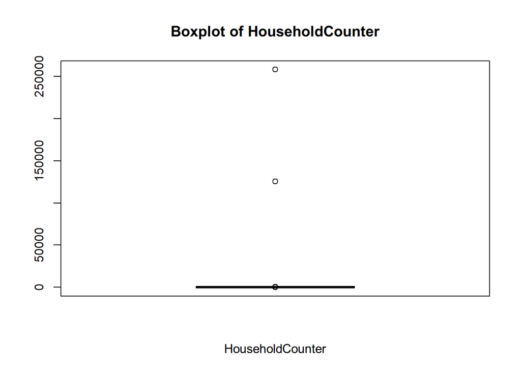

```r
boxplot(aser_child_household_tib$HouseholdCounter,
        main = "Boxplot of HouseholdCounter",
        xlab = "HouseholdCounter")
```

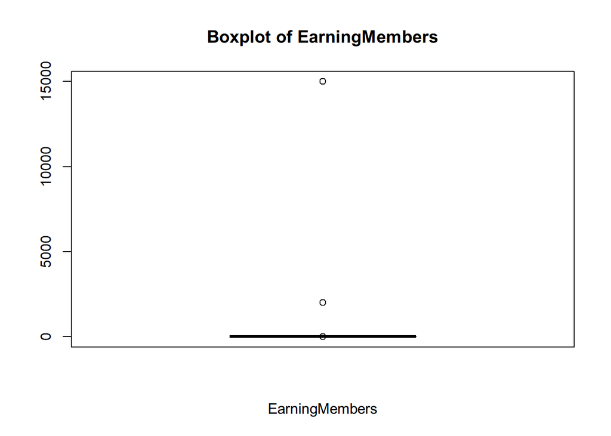

```r
boxplot(aser_child_household_tib$EarningMembers,
        main = "Boxplot of EarningMembers",
        xlab = "EarningMembers")
```

```r
# Let's just try to find out which is the outlier value

max(aser_child_household_tib$HouseholdCounter)
```

```
## [1] 258096
```

```r
max(aser_child_household_tib$EarningMembers)
```

```
## [1] 15000
```

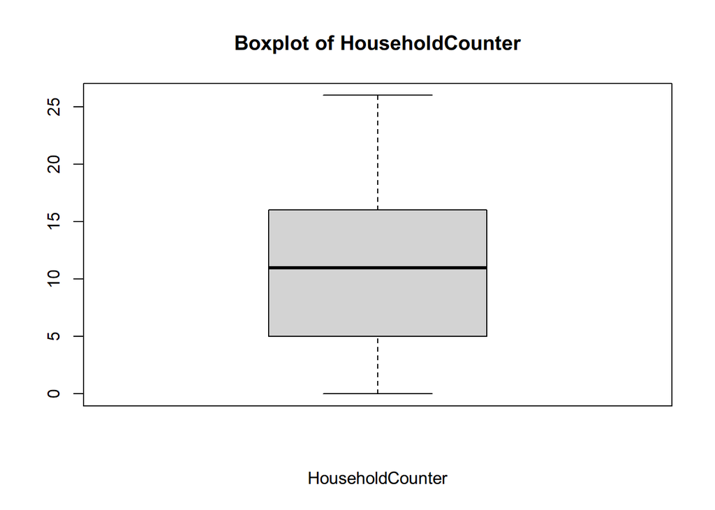

```r
# Fairly assuming that the household and earning members cannot be more than 30, we will remove the outlier value by filtering out using this criteria.

aser_child_household_tib <- aser_child_household_tib %>%
  filter(HouseholdCounter < 30) %>% # Removing the outlier value
  filter(EarningMembers < 30) # Removing the outlier value

# Checking the boxplot again to see if the outlier has been removed

boxplot(aser_child_household_tib$HouseholdCounter,
        main = "Boxplot of HouseholdCounter",
        xlab = "HouseholdCounter")
```

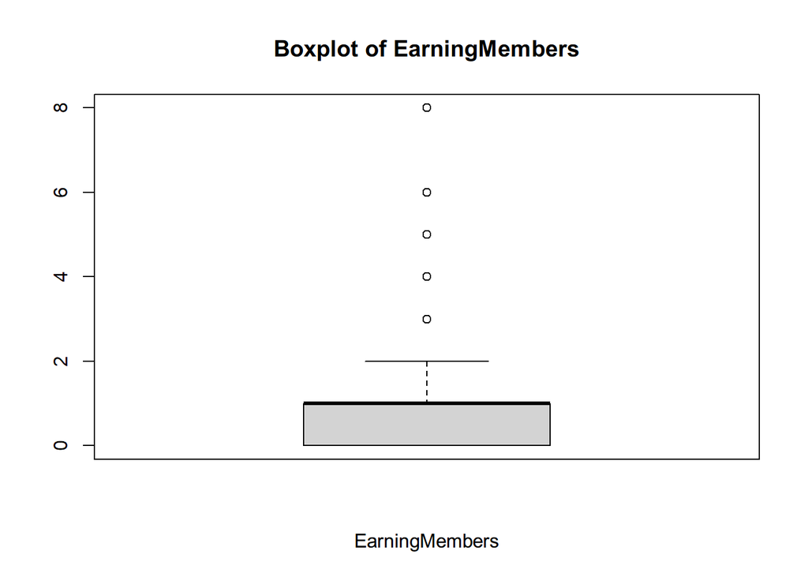

```r
boxplot(aser_child_household_tib$EarningMembers,
        main = "Boxplot of EarningMembers",
        xlab = "EarningMembers")
```

Final check for NA values in the dataset.

```r
aser_child_household_tib %>%
  summarize(total_na = sum(across(everything(), is.na))) # O NA values found in the dataset
```

```
## # A tibble: 1 × 1
##   total_na
##      <int>
## 1        0
```

```r
# Making a new tibble with the columns that will be used for clustering analysis.

aser_child_household_data_excluded <- aser_child_household_tib %>%
  select(-c(Id, IsInternetAvailable, InstitutionType)) # Excluding the columns for further analysis, we will get back to them later
```

## Multicollinearity Check

Checking for multicollinearity between the variables using the correlation matrix and the correlation plot.

```r
# Checking for multicollinearity between the variables using the correlation matrix and the correlation plot. Setting the threshold for multicollinearity at r greater than .899

corr_aser_cluster <- round(cor(aser_child_household_data_excluded), 2)

corr_aser_cluster
```

```
##                       HouseholdCounter EarningMembers  Car MotorCycle
## HouseholdCounter                  1.00           0.04 0.10       0.08
## EarningMembers                    0.04           1.00 0.43       0.41
## Car                               0.10           0.43 1.00       0.41
## MotorCycle                        0.08           0.41 0.41       1.00
## TravelTime                        0.05           0.13 0.17       0.13
## ClimateChange                     0.06          -0.01 0.08       0.02
## FloodImpacted                     0.03           0.17 0.17       0.21
## EarningImpacted                   0.04           0.14 0.17       0.19
## PsychologicalImpacted             0.05           0.09 0.19       0.18
## SchoolingAffected                 0.05           0.12 0.17       0.17
## LocalLangReadingLevel             0.02           0.13 0.17       0.23
## ArithmeticLevel                   0.01           0.18 0.20       0.25
## EnglishReadingLevel               0.01           0.16 0.21       0.25
##                       TravelTime ClimateChange FloodImpacted EarningImpacted
## HouseholdCounter            0.05          0.06          0.03            0.04
## EarningMembers              0.13         -0.01          0.17            0.14
## Car                         0.17          0.08          0.17            0.17
## MotorCycle                  0.13          0.02          0.21            0.19
## TravelTime                  1.00          0.14          0.10            0.15
## ClimateChange               0.14          1.00          0.30            0.23
## FloodImpacted               0.10          0.30          1.00            0.53
## EarningImpacted             0.15          0.23          0.53            1.00
## PsychologicalImpacted       0.11          0.36          0.70            0.40
## SchoolingAffected           0.08          0.33          0.68            0.40
## LocalLangReadingLevel       0.14          0.02          0.04            0.11
## ArithmeticLevel             0.12          0.00          0.07            0.11
## EnglishReadingLevel         0.20          0.07          0.12            0.15
##                       PsychologicalImpacted SchoolingAffected
## HouseholdCounter                       0.05              0.05
## EarningMembers                         0.09              0.12
## Car                                    0.19              0.17
## MotorCycle                             0.18              0.17
## TravelTime                             0.11              0.08
## ClimateChange                          0.36              0.33
## FloodImpacted                          0.70              0.68
## EarningImpacted                        0.40              0.40
## PsychologicalImpacted                  1.00              0.73
## SchoolingAffected                      0.73              1.00
## LocalLangReadingLevel                  0.02             -0.02
## ArithmeticLevel                        0.03              0.02
## EnglishReadingLevel                    0.07              0.06
##                       LocalLangReadingLevel ArithmeticLevel EnglishReadingLevel
## HouseholdCounter                       0.02            0.01                0.01
## EarningMembers                         0.13            0.18                0.16
## Car                                    0.17            0.20                0.21
## MotorCycle                             0.23            0.25                0.25
## TravelTime                             0.14            0.12                0.20
## ClimateChange                          0.02            0.00                0.07
## FloodImpacted                          0.04            0.07                0.12
## EarningImpacted                        0.11            0.11                0.15
## PsychologicalImpacted                  0.02            0.03                0.07
## SchoolingAffected                     -0.02            0.02                0.06
## LocalLangReadingLevel                  1.00            0.85                0.85
## ArithmeticLevel                        0.85            1.00                0.85
## EnglishReadingLevel                    0.85            0.85                1.00
```

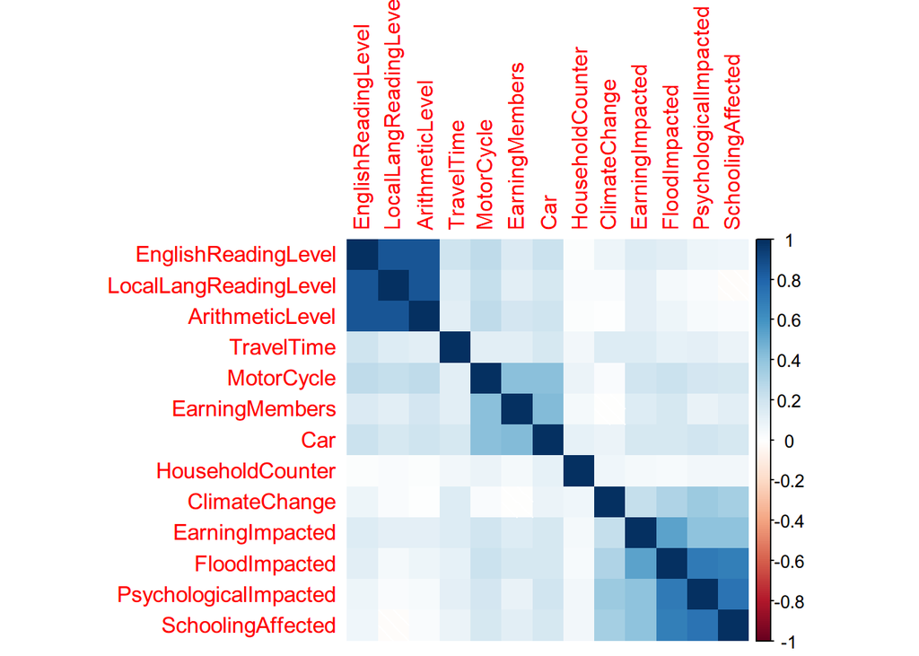

```r
corrplot::corrplot(corr_aser_cluster, method = "shade", order = "hclust")
```

```r
# Setting r > .899 as the threshold for multicollinearity. Hence, not removing any variables as they do not meet the threshold.
```

The variables `LocalLangReadingLevel`, `EnglishReadingLevel` and `ArithmeticLevel` are highly correlated but not meeting the threshold r greater than .899 for removal.